# nFK Reference Cases

`nFK` is the sum of per-component **ω<sub>max</sub>** values (Bentler 1968; Lord 1958): for each principal component of the input matrix, ω<sub>max</sub> is the maximum reliability achievable by the optimal linear composite of items measuring that component. Reading the totals below, each `nFK` value is “how many factors’ worth of reliable measurement the item set provides,” with each factor weighted by how well items recover it.

## How nFK is computed

Let $R$ be a $p \times p$ input matrix with reliability or communality on the diagonal and inter-item correlations off-diagonal. The construction proceeds in five steps.

**1. Eigendecomposition and loadings.** Eigendecompose $R = V \Lambda V'$ with $\Lambda = \mathrm{diag}(\lambda_1, \ldots, \lambda_p)$, and form the loading matrix

$$L \;=\; V
\,\mathrm{diag}\!\bigl(\sqrt{\lambda_1^{+}}, \ldots,
\sqrt{\lambda_p^{+}}\bigr), \qquad \lambda_k^{+} = \max(\lambda_k,
0).$$

Column $L_{\cdot k}$ is the loading of items on the $k$-th principal component. (When `rotate = "varimax"`, an orthogonal rotation is applied to $L$ at this point. Total nFK is invariant under orthogonal rotation; the per-component values redistribute.)

**2. Joint item+component matrix.** Stack items and components into a $2p \times 2p$ block matrix and force the full diagonal to 1:

$$B \;=\; \begin{bmatrix} R & L \\
L' & \mathbf{0} \end{bmatrix}, \qquad \mathrm{diag}(B) \,:=\,
1.$$

The diagonal swap standardizes items (top-left block) and components (bottom-right block) to unit variance; the reliability information that previously lived on the diagonal of $R$ is preserved in $L$, since the eigenvalues of $R$ shrink with the diagonal.

**3. Smooth to the nearest correlation matrix.** $B$ is rank-deficient by construction (components are exact linear combinations of items), so apply Higham’s (2002) algorithm to project to the nearest valid correlation matrix:

$$\tilde{B} \;=\; \arg\!\min_{X
\,\succeq\, 0,\;\mathrm{diag}(X)\,=\,1} \;\|X - B\|_{F}.$$

For well-behaved inputs the perturbation is negligible; the smoothing matters mainly when $R$ is rank-deficient or pseudo-non-PSD (e.g., reliability lower than off-diagonal correlation), where it is what guarantees $\tilde{R}_{xx}$ is invertible.

**4. Per-component squared multiple correlation.** Partition $\tilde{B}$ back into its top-left item block $\tilde{R}_{xx}$ and top-right item-component block $\tilde{L}$, then for each component $k$,

$$R^{2}_{k} \;=\; \tilde{L}_{\cdot k}'
\, \tilde{R}_{xx}^{-1} \, \tilde{L}_{\cdot k}.$$

This is the squared multiple correlation between items and component $k$, which equals $\omega_{\max, k}$ (Bentler 1968; Lord 1958): the maximum reliability achievable by the optimal linear composite of items measuring that component.

**5. Sum.**

$$\mathrm{nFK} \;=\; \sum_{k=1}^{p}
R^{2}_{k} \;=\; \sum_{k=1}^{p} \omega_{\max, k}.$$

**Reading the statistic.** Each $R^{2}_{k} \in [0, 1]$ is the reliability of the best item-weighted composite for that dimension; $\mathrm{nFK}$ is “how many factors’ worth of reliable measurement” the item set provides. When items measuring a factor are tau-equivalent (uniform loadings, uniform within-cluster correlation), $\omega_{\max}$ collapses to Cronbach’s $\alpha$, and for symmetric scales further to Spearman-Brown. When $R$ is rank-deficient, components with zero loadings contribute zero, so $\mathrm{rank}(R)$ is an upper bound on $\mathrm{nFK}$. When $\mathrm{diag}(R) = 1$ throughout (no measurement error encoded), every component is exactly recoverable from items and $\mathrm{nFK} = p$ regardless of off-diagonal magnitude — the off-diagonal correlation is read as true-score association, not as a measurement-information loss. To register inter-item correlation as measurement error, the reduction has to live on the diagonal as reliability or communality below 1.

## Other statistics for indexing the effective number of factors or variables in a set

The seven comparison columns to the right of `nFK` come from `poolr::meff()` (Nyholt 2004; Li & Ji 2005; Gao et al. 2008; Galwey 2009; Chen et al. 2012), with two adjustments to poolr’s defaults: the final `floor()` that poolr applies for Bonferroni correction is removed (so continuous gradations remain visible), and the two scale-invariant methods (Gao, Galwey) are reported a second time on the matrix as supplied (without forcing diag = 1). Each method reduces to a function of either eigenvalues or matrix entries.

Throughout, $\lambda_1, \ldots, \lambda_p$ are the eigenvalues of the diag-1 correlation matrix and $\lambda_{(j)}$ is the $j$-th largest. For the starred variants, $\mu_k$ replaces $\lambda_k$ — eigenvalues of the input matrix as supplied (diagonal preserved as reliability or communality). $\mathbb{I}(\cdot)$ is the indicator function and $\lfloor \cdot \rfloor$ is the floor.

**Nyholt (2004).** Moment-based; returns $p$ for equal eigenvalues (no shared variance) and 1 for a rank-1 spectrum. Bakes in the correlation-matrix assumption $\mathrm{mean}(\lambda) = 1$.

$$M_{\text{eff}} \;=\; 1 + (p -
1)\!\left(1 - \frac{\mathrm{Var}(\lambda)}{p}\right)$$

**Li & Ji (2005).** Each eigenvalue $\geq 1$ counts as a full factor (Kaiser’s rule); fractional parts contribute partially.

$$M_{\text{eff}} \;=\;
\sum_{k=1}^{p}\!\left[\,\mathbb{I}(|\lambda_k| \geq 1) +
\bigl(|\lambda_k| - \lfloor |\lambda_k|
\rfloor\bigr)\right]$$

**Gao et al. (2008).** Smallest number of leading components needed to capture a fraction $C$ of the eigenvalue sum (poolr default $C = 0.995$). Intrinsically integer.

$$M_{\text{eff}} \;=\; \min\!\left\{k
\;:\; \frac{\sum_{j=1}^{k} \lambda_{(j)}}{\sum_{j=1}^{p} \lambda_j} >
C\right\}$$

**Galwey (2009).** The participation ratio of the eigenvalue spectrum under a square-root transform of the non-negative eigenvalues. Returns $p$ for an equal spectrum, 1 for rank 1.

$$M_{\text{eff}} \;=\;
\frac{\bigl(\sum_{k=1}^{p}
\sqrt{\lambda_k^{+}}\,\bigr)^2}{\sum_{k=1}^{p} \lambda_k^{+}}, \qquad
\lambda_k^{+} = \max(\lambda_k, 0)$$

**Chen et al. (2012).** Acts on the matrix entries directly via row $\ell_C$ norms (poolr default $C = 7$). Assumes $|R_{ij}| \leq 1$ throughout, so it cannot be transferred to a non-correlation matrix.

$$M_{\text{eff}} \;=\; \sum_{i=1}^{p}
\frac{1}{\sum_{j=1}^{p} |R_{ij}|^{C}}$$

**Gao* and Galwey* (as supplied).** Identical formulas to Gao and Galwey, evaluated on $\mu_k$ rather than $\lambda_k$. Only these two transfer cleanly: their formulas are scale-invariant in the eigenvalue spectrum, so they remain meaningful when the diagonal carries reliability rather than 1. Nyholt’s $\mathrm{mean}(\lambda) = 1$, Li & Ji’s threshold of 1, and Chen’s $|R_{ij}| \leq 1$ are all violated on the as-supplied matrix.

Matrix

Matrix description

nFK

nyholt

liji

gao

galwey

chen

gao*

galwey*

```
  A B C D E F
A 1 0 0 0 0 0
B 0 1 0 0 0 0
C 0 0 1 0 0 0
D 0 0 0 1 0 0
E 0 0 0 0 1 0
F 0 0 0 0 0 1
```

#1 Identity matrix. Six perfectly reliable, uncorrelated items — six 1-item composites each at reliability 1. nFK = p = 6 is the upper bound.

6.000

6

6

6

6

6

6

6

```
  A B C D E F
A 1 1 1 1 1 1
B 1 1 1 1 1 1
C 1 1 1 1 1 1
D 1 1 1 1 1 1
E 1 1 1 1 1 1
F 1 1 1 1 1 1
```

#2 All entries 1. Six perfect copies of one factor; the unit-weighted composite has Spearman-Brown reliability (6·1)/(1+5·1) = 1 for measuring that single factor, so nFK = 1.

1.000

1

1

1

1

1

1

1

```
    A   B   C   D   E   F
A 0.7 0.7 0.7 0.7 0.7 0.7
B 0.7 0.7 0.7 0.7 0.7 0.7
C 0.7 0.7 0.7 0.7 0.7 0.7
D 0.7 0.7 0.7 0.7 0.7 0.7
E 0.7 0.7 0.7 0.7 0.7 0.7
F 0.7 0.7 0.7 0.7 0.7 0.7
```

#3 All entries 0.7. One factor measured by 6 items with diag = off-diag = 0.7. Spearman-Brown reliability of the unit composite = (6·0.7)/(1+5·0.7) = 0.933 — exactly matching nFK.

0.933

3.550

3

6

3.936

4.250

1

1

```
    A   B   C   D   E   F
A 0.7 0.0 0.0 0.0 0.0 0.0
B 0.0 0.7 0.0 0.0 0.0 0.0
C 0.0 0.0 0.7 0.0 0.0 0.0
D 0.0 0.0 0.0 0.7 0.0 0.0
E 0.0 0.0 0.0 0.0 0.7 0.0
F 0.0 0.0 0.0 0.0 0.0 0.7
```

#4 Six orthogonal items, each measured with reliability 0.7. Each item is its own 1-item factor; nFK = 6 × 0.7 = 4.2 is the sum of per-item reliabilities.

4.200

6

6

6

6

6

6

6

```
    A   B   C   D   E   F
A 1.0 0.2 0.2 0.2 0.2 0.2
B 0.2 1.0 0.2 0.2 0.2 0.2
C 0.2 0.2 1.0 0.2 0.2 0.2
D 0.2 0.2 0.2 1.0 0.2 0.2
E 0.2 0.2 0.2 0.2 1.0 0.2
F 0.2 0.2 0.2 0.2 0.2 1.0
```

#5 Six perfectly reliable items at weak inter-correlation (r = 0.2). With diag = 1, every PC is exactly recoverable from items, so nFK = p = 6 regardless of off-diagonal magnitude. Inter-correlation is not a measurement-error discount — to register it as one, encode reliability or communality < 1 on the diagonal (see #7 for the same off-diagonal structure with diag = 0.9).

6.000

5.800

5

6

5.775

6.000

6

5.775

```
    A   B   C   D   E   F
A 1.0 0.7 0.7 0.7 0.7 0.7
B 0.7 1.0 0.7 0.7 0.7 0.7
C 0.7 0.7 1.0 0.7 0.7 0.7
D 0.7 0.7 0.7 1.0 0.7 0.7
E 0.7 0.7 0.7 0.7 1.0 0.7
F 0.7 0.7 0.7 0.7 0.7 1.0
```

#6 Same setup as #5 but at r = 0.7. Same principle: with diag = 1 (no measurement error), all six dimensions are exactly recoverable from the items, so nFK = 6 even at strong inter-item correlation. See #8 for the diag = 0.9 counterpart.

6.000

3.550

3

6

3.936

4.250

6

3.936

```
    A   B   C   D   E   F
A 0.9 0.2 0.2 0.2 0.2 0.2
B 0.2 0.9 0.2 0.2 0.2 0.2
C 0.2 0.2 0.9 0.2 0.2 0.2
D 0.2 0.2 0.2 0.9 0.2 0.2
E 0.2 0.2 0.2 0.2 0.9 0.2
F 0.2 0.2 0.2 0.2 0.2 0.9
```

#7 Same off-diagonal structure as #5 (r = 0.2) but at diag = 0.9 — items now have 10% measurement error. Unlike #5, this matrix discounts each PC for that error, and inter-correlation now reduces nFK below p. Closed form: R²<sub>PC1</sub> = (0.9 + 5·0.2)/(1 + 5·0.2) = 0.95; R²<sub>k>1</sub> = (0.9 − 0.2)/(1 − 0.2) = 0.875 each; sum = 5.325.

5.325

5.800

5

6

5.775

6.000

6

5.728

```
    A   B   C   D   E   F
A 0.9 0.7 0.7 0.7 0.7 0.7
B 0.7 0.9 0.7 0.7 0.7 0.7
C 0.7 0.7 0.9 0.7 0.7 0.7
D 0.7 0.7 0.7 0.9 0.7 0.7
E 0.7 0.7 0.7 0.7 0.9 0.7
F 0.7 0.7 0.7 0.7 0.7 0.9
```

#8 Same off-diagonal structure as #6 (r = 0.7) but at diag = 0.9. Strong inter-correlation paired with imperfect reliability produces a more substantial discount than #7. Closed form: R²<sub>PC1</sub> = (0.9 + 5·0.7)/(1 + 5·0.7) = 0.978; R²<sub>k>1</sub> = (0.9 − 0.7)/(1 − 0.7) = 0.667 each; sum = 4.311.

4.311

3.550

3

6

3.936

4.250

6

3.478

```
  A B C D E F
A 1 1 1 0 0 0
B 1 1 1 0 0 0
C 1 1 1 0 0 0
D 0 0 0 1 1 1
E 0 0 0 1 1 1
F 0 0 0 1 1 1
```

#9 Two orthogonal three-item blocks, perfectly intercorrelated within (r = 1) and uncorrelated across. Per-block Spearman-Brown = (3·1)/(1+2·1) = 1; nFK = 2 × 1 = 2.

2.000

4

2

2

2

2

2

2

```
    A   B   C   D   E   F
A 0.7 0.7 0.7 0.0 0.0 0.0
B 0.7 0.7 0.7 0.0 0.0 0.0
C 0.7 0.7 0.7 0.0 0.0 0.0
D 0.0 0.0 0.0 0.7 0.7 0.7
E 0.0 0.0 0.0 0.7 0.7 0.7
F 0.0 0.0 0.0 0.7 0.7 0.7
```

#10 Same block structure as #9 but scaled by 0.7. Per-block Spearman-Brown = (3·0.7)/(1+2·0.7) = 0.875; nFK = 2 × 0.875 = 1.75.

1.750

5.020

4

6

4.663

5.152

2

2

```
      A     B     C    D E F
A 1.000 0.911 0.391 0.13 0 0
B 0.911 1.000 0.000 0.00 0 0
C 0.391 0.000 1.000 0.00 0 0
D 0.130 0.000 0.000 1.00 0 0
E 0.000 0.000 0.000 0.00 1 0
F 0.000 0.000 0.000 0.00 0 1
```

#11 Variable A is a perfect compound: A = 0.7·B + 0.3·C + 0.1·D, with B, C, D, E, F mutually uncorrelated unit-variance variables (so σ<sup>2</sup>(A) = 0.7<sup>2</sup> + 0.3<sup>2</sup> + 0.1<sup>2</sup> = 0.59). The correlation matrix is obtained from the covariance via `cov2cor()`. Rank 5 (A is determined by B, C, D); PC6 has zero loadings and contributes 0, while the other five PCs are perfectly recovered, giving nFK = 5.

5.000

5.667

5

5

4.886

5.312

5

4.886

## Per-component reliabilities

`nFK()` returns more than the headline total. The full output includes `r2` — the per-component ω<sub>max</sub> vector that sums to `nFK` — alongside the `PCAloadings`. The vector is independently informative: it shows which dimensions are reliably measured and which are not. Case #11 above (variable A constructed as a perfect linear combination of B, C, D, so the matrix has rank 5) makes this explicit:

```
## PC1 PC2 PC3 PC4 PC5 PC6
##   1   1   1   1   1   0
```

The first five components hit `r2 = 1` (perfectly recoverable from the items), and PC6 contributes exactly 0 — the rank-5 matrix cannot support a sixth orthogonal factor. The total `nFK = 5` is the count of unit r² entries; rank deficiency surfaces directly in the per-component vector.

## Connection to coefficient alpha and Spearman-Brown reliability

Each per-PC `R²_k` returned by `nFK()` admits a clean psychometric reading:

> `R²_k` is the **maximum reliability** of the optimal linear composite of items measuring the *k*-th principal component — equivalent to ω<sub>max</sub> (Bentler 1968; Lord 1958), the upper bound on reliability achievable by reweighting items.

When items measuring a factor are **tau-equivalent** (uniform loadings, uniform within-cluster correlation), ω<sub>max</sub> collapses to Cronbach’s α, and for symmetric scales further to Spearman-Brown. Several reference cases above are exactly tau-equivalent within their cluster, and `nFK` lands precisely on the canonical reliability formula:

Cases where nFK exactly matches the canonical reliability formula.

| Case | Structure | Expected (closed form) | nFK |
| --- | --- | --- | --- |
| #3 | 1 factor, 6 items, all r = 0.7, diag = 0.7 | Spearman-Brown(6, 0.7) = (6·0.7)/(1+5·0.7) = 0.933 | 0.933 |
| #4 | 6 orthogonal 1-item factors, each at reliability 0.7 | 6 × 0.7 = 4.200 | 4.200 |
| #9 | 2 blocks of 3 items, within-block r = 1, diag = 1 | 2 × Spearman-Brown(3, 1) = 2 × 1 = 2.000 | 2.000 |
| #10 | 2 blocks of 3 items, within-block r = 0.7, diag = 0.7 | 2 × Spearman-Brown(3, 0.7) = 2 × 0.875 = 1.750 | 1.750 |

### Why diag = 1 cases give nFK = *p*

Cases #5 and #6 (r = 0.2 and r = 0.7, both with diag = 1) both yield `nFK = 6`, regardless of off-diagonal magnitude. Under the ω<sub>max</sub> reading, this is the *correct* answer: with diag = 1 every item is its own 1-item perfectly-reliable composite, so the matrix encodes “I have six perfectly-measured dimensions” — even if those dimensions correlate.

To register inter-item correlation as a *measurement-information* loss, the reduction must live on the diagonal. That is the role of nFK’s diagonal input: it carries reliability (or communality), and the off-diagonals describe the structure of true-score associations among items. Setting r = 0.7 with diag = 1 (case #6) asks nFK to read “I have six perfectly-measured items that happen to correlate”; setting diag < 1 (as in #3, #4, #7, #8, #10) shifts the matrix toward “each item recovers less than full true-score variance,” and the formula responds accordingly. The contrast is clearest between #5 vs #7 and #6 vs #8: identical off-diagonal patterns at diag = 1 give nFK = 6, while at diag = 0.9 the same matrices give 5.325 and 4.311 respectively. Cases #5 and #6 thus serve as demonstrations of the principle — not failures of the formula.

## Rotation: total invariance, per-component redistribution

`nFK()` accepts `rotate = "none"` (default) or `rotate = "varimax"`, applied to the principal-component loadings before `r2` is computed. Total `nFK` is invariant under orthogonal rotation — the same dimensional content is being re-expressed, not changed — but the per-component `r2` values redistribute. When the question is “what is the reliability of each rotated factor?” rather than “what is the dimensionality of the set?”, the rotated `r2` vector is the primary output.

Two clean clusters of three items each (within-cluster *r* = 0.7, between-cluster *r* = 0, diagonal = 0.9):

```
## Total nFK (unrotated):  4.5833
```

```
## Total nFK (varimax):    4.5833
```

```
## Per-component r2 (unrotated):
```

```
##   PC1   PC2   PC3   PC4   PC5   PC6
## 0.958 0.958 0.667 0.667 0.667 0.667
```

```
##
## Per-component r2 (varimax):
```

```
##   RC1   RC2   RC3   RC4   RC5   RC6
## 0.948 0.948 0.667 0.667 0.677 0.677
```

The unrotated decomposition follows the closed forms from cases #7–#8 applied within each cluster: each cluster’s leading composite carries r² = (d + (k−1)r)/(1 + (k−1)r) = 2.3/2.4 = 0.958, and each within-cluster contrast carries (d−r)/(1−r) = 0.667. Varimax (with Kaiser normalization) shifts a small amount of loading mass between cluster and noise components, so the cluster components drop slightly and two of the contrast components rise — but the totals match exactly.

## Uniform-correlation sweeps

For a *p* × *p* matrix with constant diagonal *d* and constant off-diagonal *r*, the curves below trace nFK as *r* varies. One curve per reliability level *d* ∈ {0.1, 0.2, …, 1.0}; for each curve, *r* runs from 0 to *d* (beyond *r* = *d* the matrix is no longer positive semi-definite). A dotted curve at *d* = 0.99 (off the 0.1 grid) is included as a contrast point: with diag = 1.0, nFK stays at *p* for all *r*, but a 1% nudge below perfect reliability lets the statistic descend smoothly toward 1 as *r* → 0.99. Each panel uses its own y-axis so the curve shape is visible at every scale. Reference cases from the table above are annotated on the *p* = 6 panel.

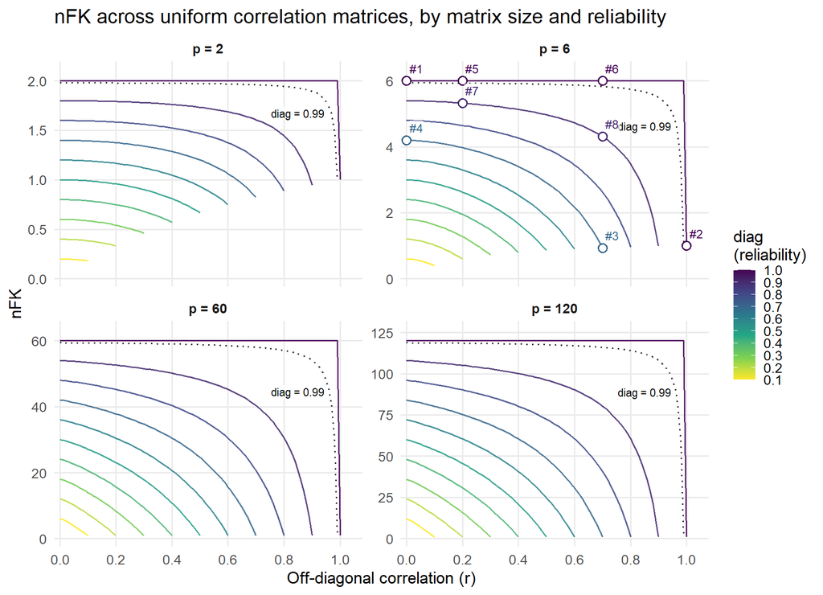